# UNHCR

In this project, I will analyze a dataset containing information about asylum applications in a given year and the progress of asylum-seekers through the refugee status determination process. Such data is available from 2000 to 2018. The country(territory of asylum/residence) is selected as Turkey and applications from all origins are covered.

## Exploratory Data Analysis

### Data Cleaning

```python
#import required packages

import requests
import folium
import pandas as pd
import numpy as np
#conda install -c conda-forge folium
```

```python
df = pd.read_csv('unhcr.csv',skiprows=3)
display(df)
```

|  | Year | Country / territory of asylum/residence | Origin | RSD procedure type / level | Tota pending start-year | of which UNHCR-assisted | Applied during year | statistics.filter.decisions_recognized | statistics.filter.decisions_other | Rejected | Otherwise closed | Total decisions | Total pending end-year | of which UNHCR-assisted.1 |
| --- | --- | --- | --- | --- | --- | --- | --- | --- | --- | --- | --- | --- | --- | --- |
| 0 | 2000 | Turkey | Afghanistan | U / FI | 67 | 67 | 81 | 29 | NaN | 24 | 49 | 102 | 46 | 46 |
| 1 | 2000 | Turkey | Burundi | U / FI | 1 | 1 | NaN | NaN | NaN | NaN | 1 | 1 | NaN | NaN |
| 2 | 2000 | Turkey | China | U / FI | 13 | 13 | 11 | 11 | NaN | 3 | NaN | 14 | 10 | 10 |
| 3 | 2000 | Turkey | Dem. Rep. of the Congo | U / FI | 3 | 3 | NaN | 1 | NaN | NaN | NaN | 1 | 2 | 2 |
| 4 | 2000 | Turkey | Congo | U / FI | NaN | NaN | 5 | NaN | NaN | 1 | NaN | 1 | 4 | 4 |
| ... | ... | ... | ... | ... | ... | ... | ... | ... | ... | ... | ... | ... | ... | ... |
| 1742 | 2018 | Turkey | Various/Unknown | U / FI | 0 | 0 | * | 0 | 0.0 | 0 | * | * | 0 | 0 |
| 1743 | 2018 | Turkey | Yemen | U / AR | * | 0 | 0 | 0 | 0.0 | 0 | 0 | NaN | * | * |
| 1744 | 2018 | Turkey | Yemen | U / FI | 423 | 272 | 250 | 15 | 0.0 | 0 | 50 | 65 | 608 | 270 |
| 1745 | 2018 | Turkey | Zambia | U / FI | * | * | 0 | 0 | 0.0 | 0 | 0 | NaN | * | * |
| 1746 | 2018 | Turkey | Zimbabwe | U / FI | 39 | 38 | 26 | 6 | 0.0 | 0 | 0 | 6 | 59 | 50 |

1747 rows × 14 columns

In our DataFrame, the **NaN** values represent the missing values which point out the lack of data collection. Moreover, some of the values are shown by * indicating the redacted values.

```python
df.info()
```

```
<class 'pandas.core.frame.DataFrame'>
RangeIndex: 1747 entries, 0 to 1746
Data columns (total 14 columns):
Year                                       1747 non-null int64
Country / territory of asylum/residence    1747 non-null object
Origin                                     1747 non-null object
RSD procedure type / level                 1747 non-null object
Tota pending start-year                    1366 non-null object
of which UNHCR-assisted                    1357 non-null object
Applied during year                        1436 non-null object
statistics.filter.decisions_recognized     705 non-null object
statistics.filter.decisions_other          117 non-null float64
Rejected                                   712 non-null object
Otherwise closed                           1171 non-null object
Total decisions                            1349 non-null object
Total pending end-year                     1422 non-null object
of which UNHCR-assisted.1                  1395 non-null object
dtypes: float64(1), int64(1), object(12)
memory usage: 191.2+ KB
```

We got object typed columns for most of the attributes. Looking at the data, we expect integer type for the columns with numerical values. Having the correct type will be very important to perform several analysis. We will deal with this problem in the later on.

```python
df.describe(include=['int64','float64'])
```

|  | Year | statistics.filter.decisions_other |
| --- | --- | --- |
| count | 1747.000000 | 117.0 |
| mean | 2011.189468 | 0.0 |
| std | 4.771304 | 0.0 |
| min | 2000.000000 | 0.0 |
| 25% | 2008.000000 | 0.0 |
| 50% | 2012.000000 | 0.0 |
| 75% | 2015.000000 | 0.0 |
| max | 2018.000000 | 0.0 |

Here, "statistics.filter.decisions_other" column is redundant. We can understand this looking at the max, min and standard deviation values. Since all of these theree values are 0, we can conclude that each row is filled with 0. Therefore, "the statistics.filter.decisions_other" column has no meaning and we can drop it from our table.

```python
df= df.drop(columns=['statistics.filter.decisions_other'])
df
```

|  | Year | Country / territory of asylum/residence | Origin | RSD procedure type / level | Tota pending start-year | of which UNHCR-assisted | Applied during year | statistics.filter.decisions_recognized | Rejected | Otherwise closed | Total decisions | Total pending end-year | of which UNHCR-assisted.1 |
| --- | --- | --- | --- | --- | --- | --- | --- | --- | --- | --- | --- | --- | --- |
| 0 | 2000 | Turkey | Afghanistan | U / FI | 67 | 67 | 81 | 29 | 24 | 49 | 102 | 46 | 46 |
| 1 | 2000 | Turkey | Burundi | U / FI | 1 | 1 | NaN | NaN | NaN | 1 | 1 | NaN | NaN |
| 2 | 2000 | Turkey | China | U / FI | 13 | 13 | 11 | 11 | 3 | NaN | 14 | 10 | 10 |
| 3 | 2000 | Turkey | Dem. Rep. of the Congo | U / FI | 3 | 3 | NaN | 1 | NaN | NaN | 1 | 2 | 2 |
| 4 | 2000 | Turkey | Congo | U / FI | NaN | NaN | 5 | NaN | 1 | NaN | 1 | 4 | 4 |
| ... | ... | ... | ... | ... | ... | ... | ... | ... | ... | ... | ... | ... | ... |
| 1742 | 2018 | Turkey | Various/Unknown | U / FI | 0 | 0 | * | 0 | 0 | * | * | 0 | 0 |
| 1743 | 2018 | Turkey | Yemen | U / AR | * | 0 | 0 | 0 | 0 | 0 | NaN | * | * |
| 1744 | 2018 | Turkey | Yemen | U / FI | 423 | 272 | 250 | 15 | 0 | 50 | 65 | 608 | 270 |
| 1745 | 2018 | Turkey | Zambia | U / FI | * | * | 0 | 0 | 0 | 0 | NaN | * | * |
| 1746 | 2018 | Turkey | Zimbabwe | U / FI | 39 | 38 | 26 | 6 | 0 | 0 | 6 | 59 | 50 |

1747 rows × 13 columns

```python
df.describe(include=['object'])
```

|  | Country / territory of asylum/residence | Origin | RSD procedure type / level | Tota pending start-year | of which UNHCR-assisted | Applied during year | statistics.filter.decisions_recognized | Rejected | Otherwise closed | Total decisions | Total pending end-year | of which UNHCR-assisted.1 |
| --- | --- | --- | --- | --- | --- | --- | --- | --- | --- | --- | --- | --- |
| count | 1747 | 1747 | 1747 | 1366 | 1357 | 1436 | 705 | 712 | 1171 | 1349 | 1422 | 1395 |
| unique | 1 | 104 | 3 | 249 | 249 | 234 | 138 | 85 | 171 | 214 | 265 | 253 |
| top | Turkey | Afghanistan | U / FI | 1 | 1 | 1 | 1 | 1 | 1 | 1 | 1 | 1 |
| freq | 1747 | 45 | 1123 | 275 | 274 | 305 | 139 | 181 | 299 | 315 | 288 | 280 |

For the sake of simplicity, we can rename the "statistics.filter.decisions_recognized" column as "Recognized" Looking at the table above, we can see that "Country / territory of asylum/residence" column has a unique value, which is Turkey. So, we do not need to keep this column, we will drop it.

```python
df = df.rename(columns={'statistics.filter.decisions_recognized': 'Recognized',
                       'Tota pending start-year':'Total pending start-year'})
df = df.drop(columns=['Country / territory of asylum/residence'])
df
```

|  | Year | Origin | RSD procedure type / level | Total pending start-year | of which UNHCR-assisted | Applied during year | Recognized | Rejected | Otherwise closed | Total decisions | Total pending end-year | of which UNHCR-assisted.1 |
| --- | --- | --- | --- | --- | --- | --- | --- | --- | --- | --- | --- | --- |
| 0 | 2000 | Afghanistan | U / FI | 67 | 67 | 81 | 29 | 24 | 49 | 102 | 46 | 46 |
| 1 | 2000 | Burundi | U / FI | 1 | 1 | NaN | NaN | NaN | 1 | 1 | NaN | NaN |
| 2 | 2000 | China | U / FI | 13 | 13 | 11 | 11 | 3 | NaN | 14 | 10 | 10 |
| 3 | 2000 | Dem. Rep. of the Congo | U / FI | 3 | 3 | NaN | 1 | NaN | NaN | 1 | 2 | 2 |
| 4 | 2000 | Congo | U / FI | NaN | NaN | 5 | NaN | 1 | NaN | 1 | 4 | 4 |
| ... | ... | ... | ... | ... | ... | ... | ... | ... | ... | ... | ... | ... |
| 1742 | 2018 | Various/Unknown | U / FI | 0 | 0 | * | 0 | 0 | * | * | 0 | 0 |
| 1743 | 2018 | Yemen | U / AR | * | 0 | 0 | 0 | 0 | 0 | NaN | * | * |
| 1744 | 2018 | Yemen | U / FI | 423 | 272 | 250 | 15 | 0 | 50 | 65 | 608 | 270 |
| 1745 | 2018 | Zambia | U / FI | * | * | 0 | 0 | 0 | 0 | NaN | * | * |
| 1746 | 2018 | Zimbabwe | U / FI | 39 | 38 | 26 | 6 | 0 | 0 | 6 | 59 | 50 |

1747 rows × 12 columns

```python
df.info()
```

```
<class 'pandas.core.frame.DataFrame'>
RangeIndex: 1747 entries, 0 to 1746
Data columns (total 12 columns):
Year                          1747 non-null int64
Origin                        1747 non-null object
RSD procedure type / level    1747 non-null object
Total pending start-year      1366 non-null object
of which UNHCR-assisted       1357 non-null object
Applied during year           1436 non-null object
Recognized                    705 non-null object
Rejected                      712 non-null object
Otherwise closed              1171 non-null object
Total decisions               1349 non-null object
Total pending end-year        1422 non-null object
of which UNHCR-assisted.1     1395 non-null object
dtypes: int64(1), object(11)
memory usage: 163.9+ KB
```

In our data set only two columns('Origin','RSD procedure type / level') contain string values, the rest contains numerical values. We can see that there exist no missing values for these two columns, only numerical values are missing. Therefore, we can fill the missing values by 0.

```python
df = df.replace(np.nan, 0)
```

```python
# Replace all missing values by 0
df.info()
```

```
<class 'pandas.core.frame.DataFrame'>
RangeIndex: 1747 entries, 0 to 1746
Data columns (total 12 columns):
Year                          1747 non-null int64
Origin                        1747 non-null object
RSD procedure type / level    1747 non-null object
Total pending start-year      1747 non-null object
of which UNHCR-assisted       1747 non-null object
Applied during year           1747 non-null object
Recognized                    1747 non-null object
Rejected                      1747 non-null object
Otherwise closed              1747 non-null object
Total decisions               1747 non-null object
Total pending end-year        1747 non-null object
of which UNHCR-assisted.1     1747 non-null object
dtypes: int64(1), object(11)
memory usage: 163.9+ KB
```

We do not have missing values any more. Still, we have redacted values which are repsented by *. To exlude these values from our analysis we will replace them with NaN value.

```python
df = df.replace('*', np.nan)
```

```python
df.describe()
```

|  | Year |
| --- | --- |
| count | 1747.000000 |
| mean | 2011.189468 |
| std | 4.771304 |
| min | 2000.000000 |
| 25% | 2008.000000 |
| 50% | 2012.000000 |
| 75% | 2015.000000 |
| max | 2018.000000 |

```python
df[df['Year']==2018].count()
```

```
Year                          117
Origin                        117
RSD procedure type / level    117
Total pending start-year       72
of which UNHCR-assisted        85
Applied during year            91
Recognized                    104
Rejected                      112
Otherwise closed               91
Total decisions                90
Total pending end-year         77
of which UNHCR-assisted.1      87
dtype: int64
```

```python
df = df.dropna()
df.shape
```

```
(1656, 12)
```

91 rows with redacted numbers are removed from the data set. Note that all of the recated values belong to 2018. Out of 117 records from 2018, 91 rows contain redacted values. Therefore, it is more accurate to exlude records of 2018 from our analysis.

```python
df = df[df['Year']!= 2018]
df.shape
```

```
(1630, 12)
```

```python
columns = ['Total pending start-year' ,'of which UNHCR-assisted','Applied during year','Recognized',\
           'Rejected','Otherwise closed', 'Total decisions','Total pending end-year','of which UNHCR-assisted.1']
df[columns] = df[columns].astype(int)
```

Let's explore our DataFrame in more detail. At first glance, we can observe two relationships.

**Total decisions = Recognized + Rejected +Otherwise closed**\ **Total decisions = Total pending start-year + Applied during year- Total pending end-year**

We need to check the correctness of these equations.

```python
sum(df['Total decisions']== df['Recognized']+df['Rejected'] +df['Otherwise closed'])
```

```
1630
```

```python
sum(df['Total decisions'] == df['Total pending start-year']+ df['Applied during year'] - df['Total pending end-year'] )
```

```
1630
```

### Let's analyse the acceptance rate of asylum applications

```python
# some imports to set up plotting
import matplotlib.pyplot as plt
# pip install seaborn
import seaborn as sns
# Graphics in retina format are more sharp and legible
%config InlineBackend.figure_format = 'retina'
```

Let's look at the total number of applications based on years

```python
columns_to_sum = ['Total pending start-year' ,'of which UNHCR-assisted','Applied during year','Recognized',\
           'Rejected','Otherwise closed', 'Total decisions','Total pending end-year','of which UNHCR-assisted.1']
```

```python
df_year_based = df.groupby(['Year'])[columns_to_sum].sum().reset_index()
df_year_based
```

|  | Year | Total pending start-year | of which UNHCR-assisted | Applied during year | Recognized | Rejected | Otherwise closed | Total decisions | Total pending end-year | of which UNHCR-assisted.1 |
| --- | --- | --- | --- | --- | --- | --- | --- | --- | --- | --- |
| 0 | 2000 | 5134 | 5134 | 5685 | 2716 | 1698 | 1196 | 5610 | 5209 | 5209 |
| 1 | 2001 | 5209 | 5209 | 5041 | 2869 | 2114 | 1091 | 6074 | 4176 | 4176 |
| 2 | 2002 | 4176 | 4176 | 3795 | 2885 | 1968 | 527 | 5380 | 2591 | 2591 |
| 3 | 2003 | 2591 | 2591 | 3952 | 2343 | 509 | 238 | 3090 | 3453 | 3453 |
| 4 | 2004 | 3453 | 3453 | 3908 | 1690 | 1742 | 0 | 3432 | 3929 | 3929 |
| 5 | 2005 | 3929 | 3929 | 3921 | 1368 | 377 | 1233 | 2978 | 4872 | 4872 |
| 6 | 2006 | 4872 | 4872 | 5101 | 1895 | 711 | 1148 | 3754 | 6219 | 6219 |
| 7 | 2007 | 6219 | 6219 | 8368 | 7066 | 523 | 1809 | 9398 | 5189 | 5189 |
| 8 | 2008 | 5189 | 5189 | 13811 | 8646 | 679 | 2558 | 11883 | 7117 | 7105 |
| 9 | 2009 | 7106 | 7106 | 8943 | 6074 | 1161 | 2827 | 10062 | 5987 | 5987 |
| 10 | 2010 | 5987 | 5987 | 11555 | 6485 | 1959 | 2383 | 10827 | 6715 | 6715 |
| 11 | 2011 | 6715 | 6715 | 17854 | 9329 | 681 | 3595 | 13605 | 10964 | 10964 |
| 12 | 2012 | 10964 | 10964 | 27302 | 10892 | 626 | 2952 | 14470 | 23796 | 23796 |
| 13 | 2013 | 23796 | 23706 | 46621 | 14160 | 1556 | 2234 | 17950 | 52467 | 52467 |
| 14 | 2014 | 52466 | 52466 | 88925 | 22454 | 983 | 11576 | 35013 | 106378 | 106378 |
| 15 | 2015 | 114804 | 114804 | 134826 | 15165 | 1213 | 20844 | 37222 | 212408 | 212408 |
| 16 | 2016 | 212408 | 212408 | 79663 | 18423 | 968 | 26725 | 46116 | 245955 | 245955 |
| 17 | 2017 | 245955 | 245955 | 126917 | 15443 | 852 | 47722 | 64017 | 308855 | 170126 |

```python
import chart_studio.plotly as py
import plotly.offline as pyoff
import plotly.graph_objs as go

#initiate visualization library for jupyter notebook
pyoff.init_notebook_mode()
```

```python
plot_data = [
    go.Scatter(
        x=df_year_based['Year'],
        y=df_year_based['Total decisions'],
        name = 'Total decisions'
    ),
    go.Scatter(
        x=df_year_based['Year'],
        y=df_year_based['Recognized'],
        name = 'Recognized'
    ),
    go.Scatter(
        x=df_year_based['Year'],
        y=df_year_based['Rejected'],
        name = 'Rejected'
    ),
    go.Scatter(
        x=df_year_based['Year'],
        y=df_year_based['Otherwise closed'],
        name = 'Otherwise closed'
    )
]

plot_layout = go.Layout(
        xaxis={"type": "category"},
        title='Total Number of Decisions'
    )
fig = go.Figure(data=plot_data, layout=plot_layout)
pyoff.iplot(fig)
```

[interactive chart not shown]

```python
#Analyze total pending start-year versus total pending end-year
df_pending = pd.melt(frame = df_year_based, id_vars= 'Year',value_vars = ['Total pending start-year','Total pending end-year'],
       var_name = 'Period',value_name= 'Total number')
display(df_pending.head())
```

|  | Year | Period | Total number |
| --- | --- | --- | --- |
| 0 | 2000 | Total pending start-year | 5134 |
| 1 | 2001 | Total pending start-year | 5209 |
| 2 | 2002 | Total pending start-year | 4176 |
| 3 | 2003 | Total pending start-year | 2591 |
| 4 | 2004 | Total pending start-year | 3453 |

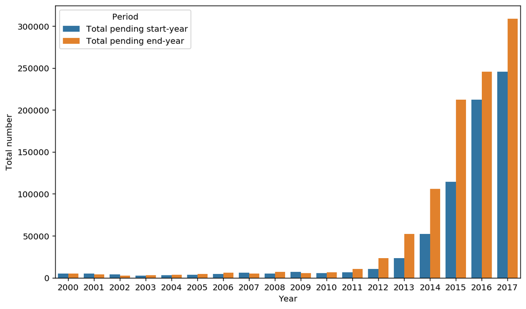

```python
plt.figure(figsize=(10, 6))

ax = sns.barplot(x="Year", y="Total number", hue="Period", data=df_pending)
```

Assuming that all applications are recorded by UNHCR, the chart above shows that the total number pending applications sharply increased from 2012 to 2017.

Let's look at the total number of applications based on **origins**.

```python
df_origin_based = df.groupby(['Origin'])[columns_to_sum].sum().reset_index()
df_origin_based.head()
```

|  | Origin | Total pending start-year | of which UNHCR-assisted | Applied during year | Recognized | Rejected | Otherwise closed | Total decisions | Total pending end-year | of which UNHCR-assisted.1 |
| --- | --- | --- | --- | --- | --- | --- | --- | --- | --- | --- |
| 0 | Afghanistan | 286100 | 286099 | 216760 | 10500 | 2292 | 46218 | 59010 | 443850 | 365053 |
| 1 | Algeria | 134 | 134 | 132 | 5 | 29 | 89 | 123 | 143 | 138 |
| 2 | Angola | 43 | 43 | 28 | 4 | 4 | 20 | 28 | 43 | 42 |
| 3 | Armenia | 1 | 1 | 2 | 1 | 0 | 1 | 2 | 1 | 1 |
| 4 | Azerbaijan | 5 | 5 | 16 | 14 | 0 | 2 | 16 | 5 | 5 |

We have applications from 102 different origins. Let's focus on the applications from 10 different countries with the highest total number of decisions.

```python
Top10 = df_origin_based.sort_values(by='Total decisions',ascending = False)['Origin'].head(10)
```

```python
#Analyze application acceptance rate based for most active 10 countries
df_top10 = df_origin_based[df_origin_based['Origin'].isin(Top10)]
df_acceptance_top10 = pd.melt(frame = df_top10, id_vars= 'Origin',value_vars = ['Recognized','Rejected','Otherwise closed'],
       var_name = 'Status',value_name= 'Total number')
```

[output not shown]

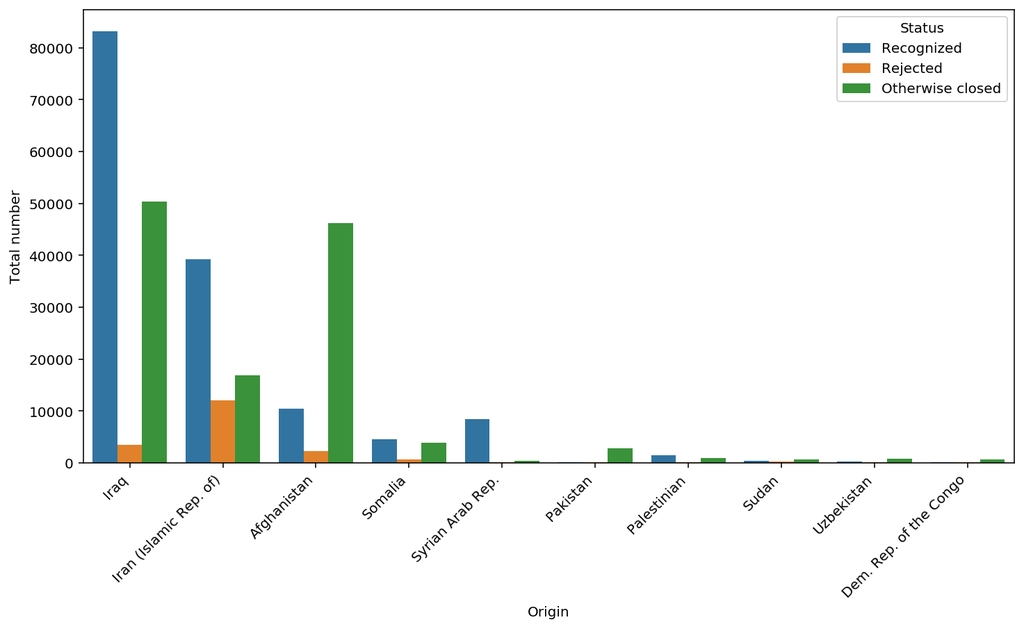

```python
plt.figure(figsize=(12, 6))
chart = sns.barplot(x="Origin", y="Total number", hue="Status", data=df_acceptance_top10, order = Top10)

chart.set_xticklabels(
    chart.get_xticklabels(),
    rotation=45,
    horizontalalignment='right',
    fontweight='light',
    fontsize='medium'
)
```

```python
#Total number of applications
```

```python
plot_data = [
    go.Bar(
        x=df_year_based['Year'],
        y=df_year_based['Applied during year'],
        name = 'Applied during year',
        marker_color='#ff7f0e'
    ),
    go.Bar(
        x=df_year_based['Year'],
        y=df_year_based['Total decisions'],
        name = 'Total decisions',
        marker_color='#2ca02c'
    ),
    go.Scatter(x=df_year_based['Year'],
           y=df_year_based['Total pending end-year'],
           name='Total pending end-year',
        marker_color ='#d62728'),

    go.Scatter(x=df_year_based['Year'],
           y=df_year_based['Total pending start-year'],
           name='Total pending end-year',
           marker_color='#1f77b4')

]

plot_layout = go.Layout(
        xaxis={"type": "category"},
        title='Total Number of Applications'
    )
fig = go.Figure(data=plot_data, layout=plot_layout)
pyoff.iplot(fig)
```

[interactive chart not shown]

```python
# Find 5 countries with highest number of application
Top5 = df_origin_based.sort_values(by='Applied during year',ascending = False)['Origin'].head(5)
df_sum= df.groupby(['Year','Origin'])[columns_to_sum].sum().reset_index()
df_top5 = df_sum[df_sum['Origin'].isin(Top5)]
display(df_top5)
```

|  | Year | Origin | Total pending start-year | of which UNHCR-assisted | Applied during year | Recognized | Rejected | Otherwise closed | Total decisions | Total pending end-year | of which UNHCR-assisted.1 |
| --- | --- | --- | --- | --- | --- | --- | --- | --- | --- | --- | --- |
| 0 | 2000 | Afghanistan | 67 | 67 | 81 | 29 | 24 | 49 | 102 | 46 | 46 |
| 10 | 2000 | Iran (Islamic Rep. of) | 2772 | 2772 | 3860 | 2197 | 774 | 528 | 3499 | 3133 | 3133 |
| 11 | 2000 | Iraq | 2177 | 2177 | 1641 | 454 | 865 | 563 | 1882 | 1936 | 1936 |
| 24 | 2000 | Somalia | 4 | 4 | 11 | 6 | 1 | 4 | 11 | 4 | 4 |
| 28 | 2000 | Syrian Arab Rep. | 1 | 1 | 3 | 1 | 0 | 1 | 2 | 2 | 2 |
| ... | ... | ... | ... | ... | ... | ... | ... | ... | ... | ... | ... |
| 962 | 2017 | Afghanistan | 114693 | 114693 | 67357 | 2687 | 1 | 21552 | 24240 | 157810 | 79020 |
| 996 | 2017 | Iran (Islamic Rep. of) | 24626 | 24626 | 9989 | 2204 | 812 | 5984 | 9000 | 25615 | 16115 |
| 997 | 2017 | Iraq | 99678 | 99678 | 44523 | 10207 | 7 | 18330 | 28544 | 115657 | 68944 |
| 1027 | 2017 | Somalia | 1224 | 1224 | 1447 | 88 | 4 | 434 | 526 | 2145 | 1645 |
| 1033 | 2017 | Syrian Arab Rep. | 180 | 180 | 18 | 4 | 0 | 31 | 35 | 163 | 63 |

90 rows × 11 columns

```python
Years = np.arange(2000, 2018).tolist()
plot_data = [
    go.Bar(
        x=Years,
        y=df_top5[df_top5['Origin']=='Iraq']['Applied during year'],
        name = 'Iraq'
    ),
    go.Bar(
        x=Years,
        y=df_top5[df_top5['Origin']=='Afghanistan']['Applied during year'],
        name = 'Afghanistan'
    ),
    go.Bar(
        x=Years,
        y=df_top5[df_top5['Origin']=='Iran (Islamic Rep. of)']['Applied during year'],
        name = 'Iran'
    ),

    go.Bar(
        x=Years,
        y=df_top5[df_top5['Origin']=='Somalia']['Applied during year'],
        name = 'Somalia'
    ),
     go.Bar(
        x=Years,
        y=df_top5[df_top5['Origin']=='Syrian Arab Rep.']['Applied during year'],
        name = 'Syria'
    )

]
plot_layout = go.Layout(
        xaxis={"type": "category"},
        title='Total Number of Applications'
    )
fig = go.Figure(data=plot_data, layout=plot_layout)
fig.update_layout(barmode='stack')
pyoff.iplot(fig)
```

[interactive chart not shown]

```python
import plotly.express as px
df_map = px.data.gapminder()
```

```python
country_list =df_map['country'].unique()
country_list
```

```
array(['Afghanistan', 'Albania', 'Algeria', 'Angola', 'Argentina',
       'Australia', 'Austria', 'Bahrain', 'Bangladesh', 'Belgium',
       'Benin', 'Bolivia', 'Bosnia and Herzegovina', 'Botswana', 'Brazil',
       'Bulgaria', 'Burkina Faso', 'Burundi', 'Cambodia', 'Cameroon',
       'Canada', 'Central African Republic', 'Chad', 'Chile', 'China',
       'Colombia', 'Comoros', 'Congo, Dem. Rep.', 'Congo, Rep.',
       'Costa Rica', "Cote d'Ivoire", 'Croatia', 'Cuba', 'Czech Republic',
       'Denmark', 'Djibouti', 'Dominican Republic', 'Ecuador', 'Egypt',
       'El Salvador', 'Equatorial Guinea', 'Eritrea', 'Ethiopia',
       'Finland', 'France', 'Gabon', 'Gambia', 'Germany', 'Ghana',
       'Greece', 'Guatemala', 'Guinea', 'Guinea-Bissau', 'Haiti',
       'Honduras', 'Hong Kong, China', 'Hungary', 'Iceland', 'India',
       'Indonesia', 'Iran', 'Iraq', 'Ireland', 'Israel', 'Italy',
       'Jamaica', 'Japan', 'Jordan', 'Kenya', 'Korea, Dem. Rep.',
       'Korea, Rep.', 'Kuwait', 'Lebanon', 'Lesotho', 'Liberia', 'Libya',
       'Madagascar', 'Malawi', 'Malaysia', 'Mali', 'Mauritania',
       'Mauritius', 'Mexico', 'Mongolia', 'Montenegro', 'Morocco',
       'Mozambique', 'Myanmar', 'Namibia', 'Nepal', 'Netherlands',
       'New Zealand', 'Nicaragua', 'Niger', 'Nigeria', 'Norway', 'Oman',
       'Pakistan', 'Panama', 'Paraguay', 'Peru', 'Philippines', 'Poland',
       'Portugal', 'Puerto Rico', 'Reunion', 'Romania', 'Rwanda',
       'Sao Tome and Principe', 'Saudi Arabia', 'Senegal', 'Serbia',
       'Sierra Leone', 'Singapore', 'Slovak Republic', 'Slovenia',
       'Somalia', 'South Africa', 'Spain', 'Sri Lanka', 'Sudan',
       'Swaziland', 'Sweden', 'Switzerland', 'Syria', 'Taiwan',
       'Tanzania', 'Thailand', 'Togo', 'Trinidad and Tobago', 'Tunisia',
       'Turkey', 'Uganda', 'United Kingdom', 'United States', 'Uruguay',
       'Venezuela', 'Vietnam', 'West Bank and Gaza', 'Yemen, Rep.',
       'Zambia', 'Zimbabwe'], dtype=object)
```

```python
unhcr_country = df['Origin'].to_numpy()
unhcr_country = np.unique(unhcr_country)
unhcr_country
```

```
array(['Afghanistan', 'Algeria', 'Angola', 'Armenia', 'Azerbaijan',
       'Bahrain', 'Bangladesh', 'Belarus', 'Benin', 'Bhutan',
       'Bolivia (Plurinational State of)', 'Burkina Faso', 'Burundi',
       'Cambodia', 'Cameroon', 'Central African Rep.', 'Chad', 'Chile',
       'China', 'Congo', 'Cuba', "Côte d'Ivoire",
       "Dem. People's Rep. of Korea", 'Dem. Rep. of the Congo',
       'Djibouti', 'Dominica', 'Dominican Rep.', 'Ecuador', 'Egypt',
       'Eritrea', 'Ethiopia', 'France', 'Gabon', 'Gambia', 'Georgia',
       'Ghana', 'Guatemala', 'Guinea', 'Guinea-Bissau', 'Haiti', 'India',
       'Indonesia', 'Iran (Islamic Rep. of)', 'Iraq', 'Israel', 'Jordan',
       'Kazakhstan', 'Kenya', 'Kuwait', 'Kyrgyzstan', 'Lebanon',
       'Liberia', 'Libya', 'Malawi', 'Malaysia', 'Mali', 'Mauritania',
       'Mongolia', 'Morocco', 'Myanmar', 'Nepal', 'Niger', 'Nigeria',
       'Oman', 'Pakistan', 'Palestinian', 'Peru', 'Philippines',
       'Romania', 'Russian Federation', 'Rwanda', 'Saudi Arabia',
       'Senegal', 'Serbia and Kosovo (S/RES/1244 (1999))', 'Sierra Leone',
       'Singapore', 'Solomon Islands', 'Somalia', 'South Africa',
       'South Sudan', 'Sri Lanka', 'Stateless', 'Sudan', 'Suriname',
       'Syrian Arab Rep.', 'Tajikistan', 'Tibetan', 'Togo', 'Tunisia',
       'Turkmenistan', 'Uganda', 'Ukraine', 'United Arab Emirates',
       'United Kingdom', 'United Rep. of Tanzania',
       'United States of America', 'Uzbekistan', 'Various/Unknown',
       'Western Sahara', 'Yemen', 'Zambia', 'Zimbabwe'], dtype=object)
```

```python
df_map = df_map.loc[:,['country','iso_alpha','continent']]
df_map = df_map.drop_duplicates()
df_sum= df.groupby(['Year','Origin'])[columns_to_sum].sum().reset_index()
df_sum = df_sum.replace('Iran (Islamic Rep. of)', 'Iran')
df_sum = df_sum.replace('Dem. Rep. of the Congo', 'Congo, Rep.')
df_sum = df_sum.replace('Yemen', 'Yemen, Rep.')
df_sum = df_sum.replace('Syrian Arab Rep.', 'Syria')

df_merged = pd.merge(df_sum, df_map, left_on = 'Origin', right_on= 'country', how= 'left')

df_merged[df_merged['iso_alpha'].isnull()]
```

|  | Year | Origin | Total pending start-year | of which UNHCR-assisted | Applied during year | Recognized | Rejected | Otherwise closed | Total decisions | Total pending end-year | of which UNHCR-assisted.1 | country | iso_alpha | continent |
| --- | --- | --- | --- | --- | --- | --- | --- | --- | --- | --- | --- | --- | --- | --- |
| 4 | 2000 | Congo | 0 | 0 | 5 | 0 | 1 | 0 | 1 | 4 | 4 | NaN | NaN | NaN |
| 20 | 2000 | Palestinian | 9 | 9 | 13 | 6 | 3 | 5 | 14 | 8 | 8 | NaN | NaN | NaN |
| 22 | 2000 | Serbia and Kosovo (S/RES/1244 (1999)) | 1 | 1 | 0 | 0 | 0 | 0 | 0 | 1 | 1 | NaN | NaN | NaN |
| 26 | 2000 | Stateless | 0 | 0 | 1 | 0 | 0 | 1 | 1 | 0 | 0 | NaN | NaN | NaN |
| 29 | 2000 | Tajikistan | 7 | 7 | 0 | 0 | 0 | 0 | 0 | 7 | 7 | NaN | NaN | NaN |
| ... | ... | ... | ... | ... | ... | ... | ... | ... | ... | ... | ... | ... | ... | ... |
| 1040 | 2017 | Ukraine | 1 | 1 | 0 | 0 | 0 | 1 | 1 | 0 | 0 | NaN | NaN | NaN |
| 1041 | 2017 | United Arab Emirates | 20 | 20 | 6 | 5 | 0 | 0 | 5 | 21 | 10 | NaN | NaN | NaN |
| 1042 | 2017 | United Rep. of Tanzania | 2 | 2 | 0 | 0 | 0 | 1 | 1 | 1 | 0 | NaN | NaN | NaN |
| 1043 | 2017 | Uzbekistan | 531 | 531 | 234 | 3 | 0 | 147 | 150 | 615 | 302 | NaN | NaN | NaN |
| 1044 | 2017 | Various/Unknown | 13 | 13 | 0 | 0 | 0 | 13 | 13 | 0 | 0 | NaN | NaN | NaN |

241 rows × 14 columns

```python
#plot


fig = px.choropleth(df_merged, locations="iso_alpha", hover_name="country",color="Applied during year",\
                     animation_frame="Year", projection="natural earth",)
fig.update_geos(
    resolution=50, scope="world",
    showcountries=True, countrycolor="Black",
    showsubunits=True, subunitcolor="Blue"
)
fig.update_layout(height=500, margin={"r":0,"t":0,"l":0,"b":0})

fig.show()
```

[interactive chart not shown]